# exploration

### Exploration of Yelp Dataset, to find a features, we want to use in our model, and secondly to get a grasp of the data

```
Setting default log level to "WARN".
To adjust logging level use sc.setLogLevel(newLevel). For SparkR, use setLogLevel(newLevel).
23/06/06 20:27:18 WARN NativeCodeLoader: Unable to load native-hadoop library for your platform... using builtin-java classes where applicable
23/06/06 20:27:20 WARN Utils: Service 'SparkUI' could not bind on port 4040. Attempting port 4041.
```

### First let's get the feeling for the data

Random Sample of 5 reviews

|  | business_id | cool | date | funny | review_id | stars | text | useful_votes | user_id |
| --- | --- | --- | --- | --- | --- | --- | --- | --- | --- |
| 0 | XQfwVwDr-v0ZS3_CbbE5Xw | 0 | 2018-07-07 22:09:11 | 0 | KU_O5udG6zpxOg-VcAEodg | 3.0 | If you decide to eat here, just be aware it is... | 0 | mh_-eMZ6K5RLWhZyISBhwA |
| 1 | 7ATYjTIgM3jUlt4UM3IypQ | 1 | 2012-01-03 15:28:18 | 0 | BiTunyQ73aT9WBnpR9DZGw | 5.0 | I've taken a lot of spin classes over the year... | 1 | OyoGAe7OKpv6SyGZT5g77Q |
| 2 | YjUWPpI6HXG530lwP-fb2A | 0 | 2014-02-05 20:30:30 | 0 | saUsX_uimxRlCVr67Z4Jig | 3.0 | Family diner. Had the buffet. Eclectic assortm... | 0 | 8g_iMtfSiwikVnbP2etR0A |
| 3 | kxX2SOes4o-D3ZQBkiMRfA | 1 | 2015-01-04 00:01:03 | 0 | AqPFMleE6RsU23_auESxiA | 5.0 | Wow! Yummy, different, delicious. Our favo... | 1 | _7bHUi9Uuf5__HHc_Q8guQ |
| 4 | e4Vwtrqf-wpJfwesgvdgxQ | 1 | 2017-01-14 20:54:15 | 0 | Sx8TMOWLNuJBWer-0pcmoA | 4.0 | Cute interior and owner (?) gave us tour of up... | 1 | bcjbaE6dDog4jkNY91ncLQ |

|  | summary | useful_votes |
| --- | --- | --- |
| 0 | count | 6990280 |
| 1 | mean | 1.1846089140921394 |
| 2 | stddev | 3.253766966933363 |
| 3 | min | -1 |
| 4 | 25% | 0 |
| 5 | 50% | 0 |
| 6 | 75% | 1 |
| 7 | max | 1182 |

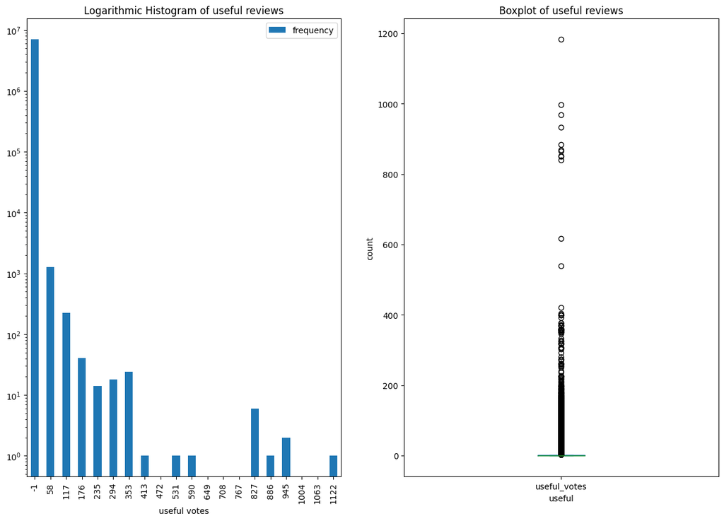

As we can see it very skewed, the 50% quantile is 0, suggesting that most of the reviews didn't get a single useful vote. That is really a problem, as the algorithm would they simple predict 0 for most of the reviews and still get good MSE. The question is whether the review with 100 votes is really 100 times more useful than the one with 1 vote. We will thus categorize the usefulness into 3 categories: 0, 1-5, 5+.

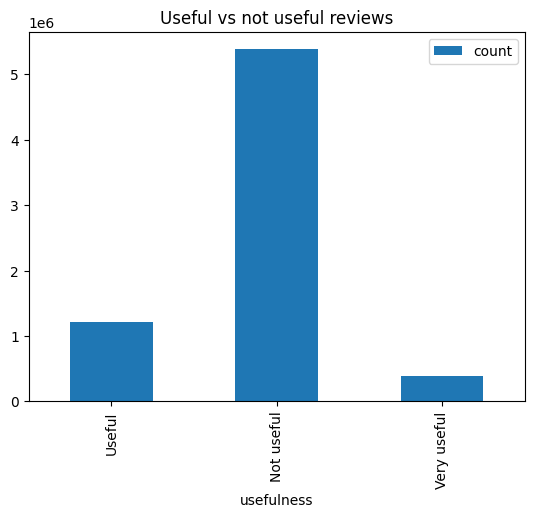

Now when we know what we are going to predict, let's look at the features.

We will start with looking at language of reviews

|  | language | count |
| --- | --- | --- |
| 0 | en | 6984985 |
| 1 | es | 2565 |
| 2 | de | 803 |
| 3 | fr | 648 |
| 4 | zh | 287 |
| 5 | pt | 222 |
| 6 | ja | 196 |
| 7 | it | 187 |
| 8 | sv | 118 |
| 9 | nl | 72 |
| 10 | da | 30 |
| 11 | tr | 24 |
| 12 | pl | 12 |
| 13 | hu | 12 |
| 14 | fi | 11 |
| 15 | vi | 10 |
| 16 | la | 9 |
| 17 | ca | 7 |
| 18 | id | 7 |
| 19 | sh | 7 |
| 20 | sl | 6 |
| 21 | az | 5 |
| 22 | ru | 5 |
| 23 | sr | 5 |
| 24 | no | 4 |
| 25 | si | 4 |
| 26 | sk | 4 |
| 27 | eo | 3 |
| 28 | ceb | 3 |
| 29 | cs | 3 |
| 30 | ro | 3 |
| 31 | uz | 2 |
| 32 | ms | 2 |
| 33 | et | 2 |
| 34 | cy | 2 |
| 35 | pms | 1 |
| 36 | nds | 1 |
| 37 | fy | 1 |
| 38 | lb | 1 |
| 39 | el | 1 |
| 40 | tl | 1 |
| 41 | kk | 1 |
| 42 | oc | 1 |
| 43 | eu | 1 |
| 44 | bs | 1 |
| 45 | als | 1 |
| 46 | nn | 1 |
| 47 | ml | 1 |
| 48 | te | 1 |
| 49 | ia | 1 |

Most of the reviews are in English, which is good, as we don't have to deal with multiple languages. We will thus use only English reviews.

Let's now look at text of the reviews

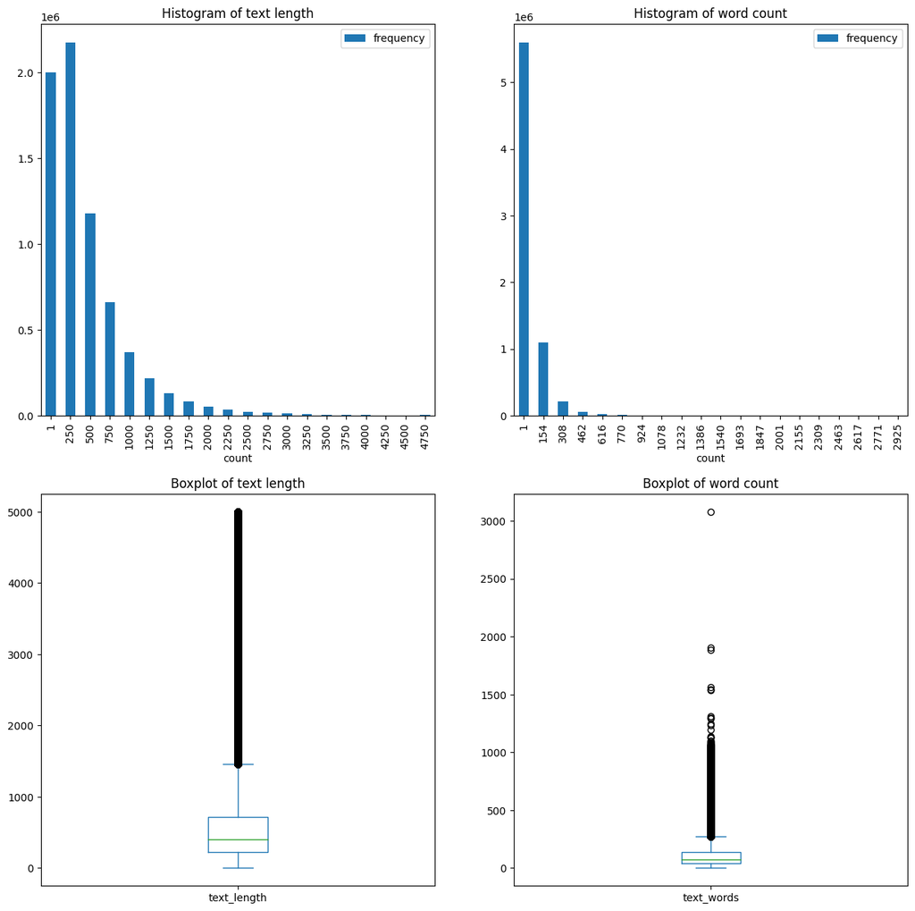

Most of the reviews are rather short, but that's not a reason to discard them. It migh be possible that they are not as informative as longer ones, let' see.

|  | correlation |
| --- | --- |
| useful_votes | 1.000000 |
| cool | 0.718529 |
| funny | 0.511803 |
| text_length | 0.244580 |
| text_words | 0.239977 |
| stars | -0.072458 |

There is correlation, but not that significant. The other votable features (cool, funny) are very corelates, but they will note be available.

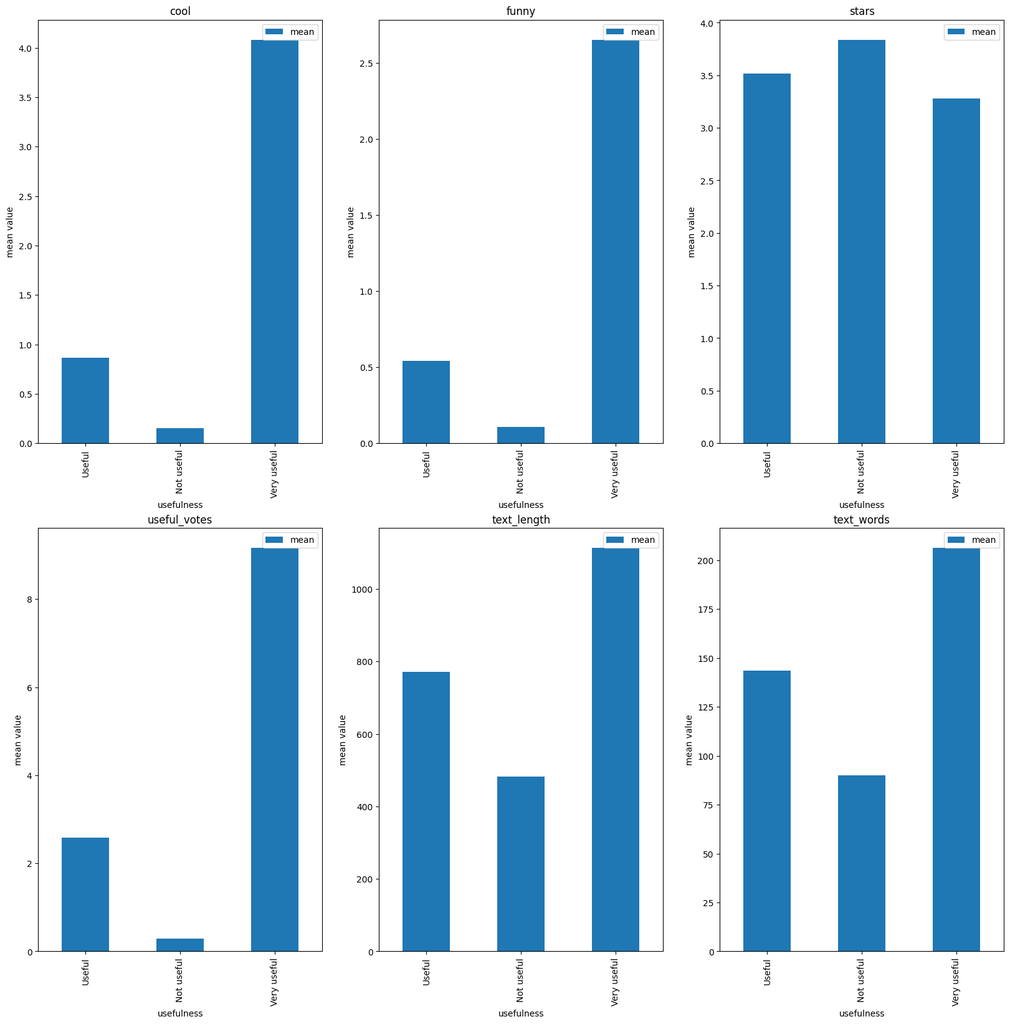

As we can see from corelations and means values, the stars really don't matter when it comes to usefulness. It's not that surprising, as the usefulness is not a rating, but rather a measure of how much people found the review helpful. While 0 correlation might suggest that feature is not useful, it's not really true in non-linear models. We will thus keep it.

We will now move onto users and their properties

Let's get feeling for the data

|  | average_stars | compliment_cool | compliment_cute | compliment_funny | compliment_hot | compliment_list | compliment_more | compliment_note | compliment_photos | compliment_plain | ... | cool | elite | fans | friends | funny | name | review_count | useful | user_id | yelping_since |
| --- | --- | --- | --- | --- | --- | --- | --- | --- | --- | --- | --- | --- | --- | --- | --- | --- | --- | --- | --- | --- | --- |
| 0 | 4.29 | 2 | 0 | 2 | 1 | 0 | 0 | 1 | 0 | 0 | ... | 13 |  | 1 | piejMEdRkGB7-1aL4lL5NQ, X0zFOU6iG95-feQKOXkgrA... | 3 | Teresa | 7 | 18 | 1McG5Rn_UDkmlkZOrsdptg | 2009-05-26 16:11:11 |
| 1 | 4.15 | 2 | 0 | 2 | 0 | 0 | 1 | 6 | 0 | 2 | ... | 19 |  | 1 | hJiJzw6obCmbGAfwrTkavQ, EMJV9rib660I4RpMsbzWbg... | 2 | Jennifer | 25 | 29 | fJZO_skqpnhk1kvomI4dmA | 2008-07-14 16:01:36 |
| 2 | 3.84 | 66 | 0 | 66 | 15 | 0 | 1 | 12 | 12 | 33 | ... | 29 |  | 9 | EPBLDry-ObheloH-NuvbvQ, 0GHsxjCk-Ynzx4Ihj8tjPQ... | 29 | Ronskee | 37 | 56 | x7YtLnBW2dUnrrpwaofVQQ | 2010-05-06 00:40:56 |
| 3 | 3.52 | 21 | 0 | 21 | 10 | 0 | 0 | 11 | 0 | 8 | ... | 203 | 2015,2016 | 5 | ElaFwOTdEpkiYPkHMpOwXQ, nbnftigv3fj8oS6k-waLYQ... | 141 | Stephanie | 201 | 555 | FT9CFS39sjZxVjCTrDHmdg | 2010-06-14 21:44:28 |
| 4 | 3.50 | 0 | 0 | 0 | 0 | 0 | 0 | 2 | 0 | 3 | ... | 98 |  | 9 | 5-cF_paDOoXPtgaAeE_XyQ, bwPqqPZ0u5ak_Lr45V1-CQ... | 76 | Jay | 15 | 119 | kggqL33iZjeHmUn1Rtdjzg | 2010-09-20 21:56:48 |

5 rows × 22 columns

```
23/06/06 20:39:11 WARN package: Truncated the string representation of a plan since it was too large. This behavior can be adjusted by setting 'spark.sql.debug.maxToStringFields'.
```

|  | summary | average_stars | compliment_cool | compliment_cute | compliment_funny | compliment_hot | compliment_list | compliment_more | compliment_note | compliment_photos | ... | cool | elite | fans | friends | funny | name | review_count | useful | user_id | yelping_since |
| --- | --- | --- | --- | --- | --- | --- | --- | --- | --- | --- | --- | --- | --- | --- | --- | --- | --- | --- | --- | --- | --- |
| 0 | count | 198514 | 198514 | 198514 | 198514 | 198514 | 198514 | 198514 | 198514 | 198514 | ... | 198514 | 198514 | 198514 | 198514 | 198514 | 198514 | 198514 | 198514 | 198514 | 198514 |
| 1 | mean | 3.624057043835692 | 2.669020824727727 | 0.130323302134862 | 2.669020824727727 | 1.7257070030325317 | 0.053573047744743446 | 0.27969815730880443 | 1.3311252606869037 | 1.0516185256455464 | ... | 23.616868331704566 | 2017.1945830363507 | 1.4687276464128474 | None | 16.646886365697128 | NaN | 23.491280211974974 | 42.172693109805856 | None | None |
| 2 | stddev | 1.1863814645688615 | 74.03425326871714 | 4.829014039556154 | 74.03425326871714 | 59.683138321087135 | 2.37629120966694 | 6.22368616586949 | 27.561233138319388 | 42.63690820165252 | ... | 478.79183716441014 | 3.9974919768405175 | 15.416211622487324 | None | 332.60778528534394 | NaN | 79.7581632364515 | 551.2420065619322 | None | None |
| 3 | min | 1.0 | 0 | 0 | 0 | 0 | 0 | 0 | 0 | 0 | ... | 0 |  | 0 | --1PqS9ZNtl5NMX-xKWg8w, dQug2pedymFjOf6niqgHcg... | 0 | Chris | 0 | 0 | --0FNOzZkEQlz8WzS3WttQ | 2004-10-14 00:26:41 |
| 4 | 25% | 3.0 | 0 | 0 | 0 | 0 | 0 | 0 | 0 | 0 | ... | 0 | 2015.0 | 0 | None | 0 | NaN | 2 | 0 | None | None |
| 5 | 50% | 3.87 | 0 | 0 | 0 | 0 | 0 | 0 | 0 | 0 | ... | 0 | 2018.0 | 0 | None | 0 | NaN | 5 | 3 | None | None |
| 6 | 75% | 4.55 | 0 | 0 | 0 | 0 | 0 | 0 | 0 | 0 | ... | 3 | 2021.0 | 0 | None | 2 | NaN | 17 | 13 | None | None |
| 7 | max | 5.0 | 13942 | 741 | 13942 | 10858 | 462 | 1727 | 6108 | 7786 | ... | 93222 | 2021 | 2451 | zzpgpo54-_P-4rzzBtOuLQ, g7Vvui4AiBQ-hRrr_3iZJA... | 84952 | 재원 | 7738 | 100480 | zzxZoMmjbUjXcWZzrE3PIw | 2022-01-19 15:23:45 |

8 rows × 23 columns

The compliment features are very skewed. Very few users actually have them non-zero. Let's see their corelations between each other.

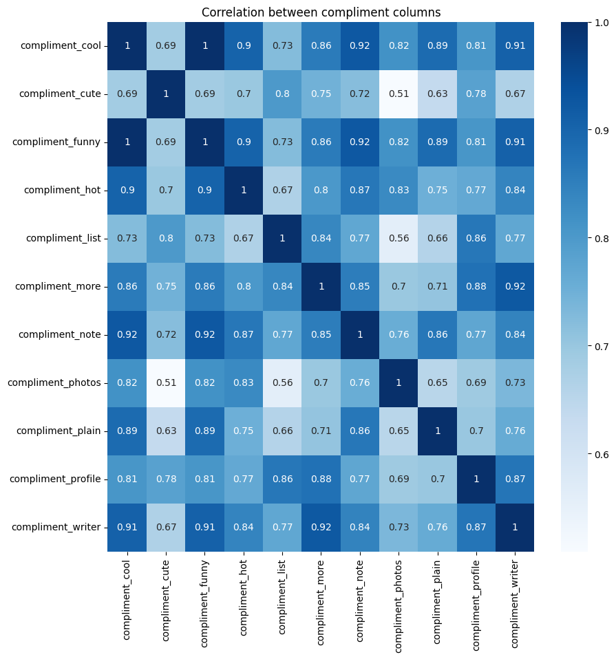

Interestingly there is high correlation between them. We will thus use only use commplient_list, complient_cute and complient_cool.

Next we will calculate how long the user is on yelp since 1970. It might be that the longer the user is on yelp, the more useful his review is and we would not use the yelping_since feature otherwise

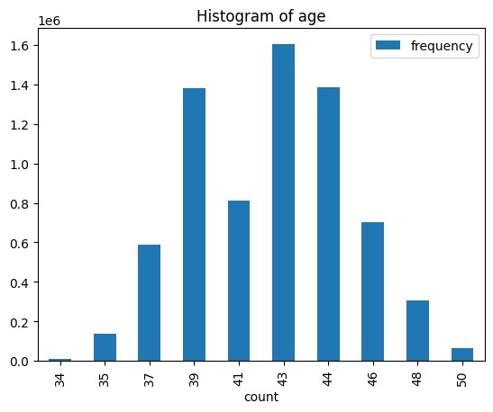

Most of the users are from 2013, showing the decreasing popularity of yelp.

Lastly we will not take all features we got and see how they correlate with the usefulness

Scatter plots of top 4 of them based on absolute correlation

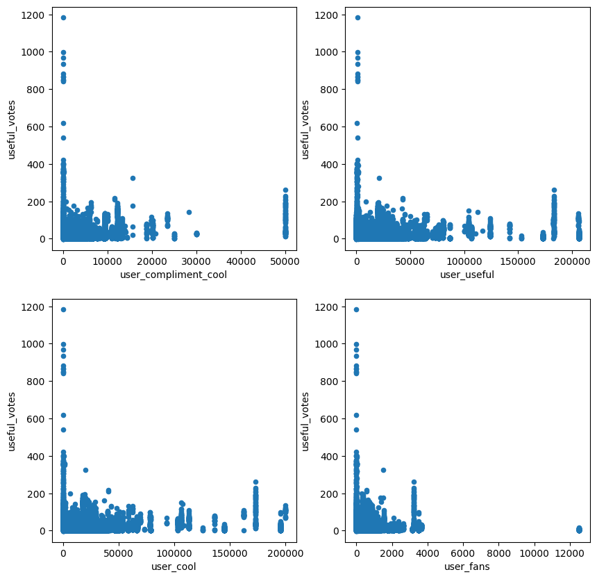

As can be seen all of them are user properties.

Finally let's see how many missing values we have in our features

|  | user_id | stars | useful_votes | text | date | user_review_count | user_useful | user_funny | user_cool | user_yelping_since | user_elite | user_fans | user_average_stars | user_compliment_cool | user_compliment_cute | user_compliment_list | user_age | text_length | text_words |
| --- | --- | --- | --- | --- | --- | --- | --- | --- | --- | --- | --- | --- | --- | --- | --- | --- | --- | --- | --- |
| 0 | 77n3enAMdlka0pZ82GT9VQ | 5.0 | 0 | I have to say that the water system that Joe s... | 2022-01-19 | NaN | NaN | NaN | NaN | None | None | NaN | NaN | NaN | NaN | NaN | NaN | 592 | 112 |
| 1 | I6G8wz_LD_8IsCPxvjs8SQ | 1.0 | 0 | They mishandled my account, overcharging me, t... | 2022-01-19 | NaN | NaN | NaN | NaN | None | None | NaN | NaN | NaN | NaN | NaN | NaN | 78 | 13 |
| 2 | 3N6-acEgosQSbipmBZKoSg | 1.0 | 0 | I recently had a 30 year old gas furnance go o... | 2022-01-19 | NaN | NaN | NaN | NaN | None | None | NaN | NaN | NaN | NaN | NaN | NaN | 2097 | 386 |
| 3 | 0oMk8hhMqiSt4G1BJjjG6g | 5.0 | 0 | ArmorTech installed three sliders and a storm ... | 2022-01-19 | NaN | NaN | NaN | NaN | None | None | NaN | NaN | NaN | NaN | NaN | NaN | 397 | 60 |
| 4 | PCS3F53ltR_svcnncSw6pw | 1.0 | 0 | My review is for att and direct tv the only re... | 2022-01-19 | NaN | NaN | NaN | NaN | None | None | NaN | NaN | NaN | NaN | NaN | NaN | 690 | 141 |

Some are missing but nothing too serious.